# MATH 497: Final Project

Remark:

Please upload your solutions of this assignment to Canvas with a file named "Final_Project_yourname.ipynb".

## Questions during the presentation

### 1. What is the training algorithm you used for training the MgNet results. Please briefly explain some hyper-parameters of this training algorithms such as: mini-batch size, learning rate.

### 2. Can you change J in the multigrid code to 5 and run the code?

### 3. How do you apply the operation of convolution $f^l-A_l * u^l$ in your code?

### 4. How are the batch size and number of iterations related?

### 5. What is the order of activation function and batch normalization in MgNet/

### 6. How to change the learning rate schedule to: divided the learning rate by 2 every 50 epochs?

### 7. Define a MgNet, which has 5 layers and the number of iterations for the first layer is 2 and the numbers of iterations for the other layers are all 1.

### 8. How do you think about the result to reduce the channel for both $u$ and $f$ to 32, meanwhile, how about increase the channel to 1024?

### 9. How will changing the number of channels affect the complexity (i.e number of parameters) of the model?

### 10. What are the differences between Multigrid codes and MgNet codes? List three differences.

### 11. Can you make a conclusion about the corresponding effects for tuning each parameter?

### 12. Can you explain the purpose of the training-validation split?

=================================================================================================================

## Problem 1 (ZZ 20 pts):

Consider the following linear system

\begin{equation}\label{matrix} A\ast u =f, \end{equation}

or equivalently $u=\arg\min \frac{1}{2} (A* v,v)_F-(f,v)_F$, where $(f,v)_F =\sum\limits_{i,j=1}^{n}f_{i,j}v_{i,j} $. Here $A\ast$ is a convolution for one channel with stride 1 and zero padding 1 $$ A=\begin{bmatrix} 0 & -1 & 0 \\ -1 & 4 & -1 \\ 0 & -1 & 0 \end{bmatrix},~~ $$

$ u \in \mathbb{R}^{n\times n} $, $ f\in \mathbb{R}^{n\times n}$ and $f_{i,j}=\dfrac{1}{(n+1)^2}.$

### Requirement:

Set $J=4$, $n=2^J-1$ and the number of iteration $M=100$. Use gradient descent method and multigrid method to solve the above problem with random initial guess $u^0$. The solution obtained by gradient descent method and multigrid method are denoted by $u_{GD}$ and $u_{MG}$ respectively.

- Plot the surface of solution $u_{GD}$ and $u_{MG}$.
- Define error $e_{GD}^m = \|A * u^{m}_{GD}- f\|_F=\sqrt{\sum\limits_{i=1}^{n}\sum\limits_{j=1}^{n} |(A * u^{m}_{GD}- f)_{i,j}}|^2 $, $m=0,1,2,3,...,M$. Similarly we can define $e_{MG}^m$. Plot the curves of $e_{GD}^m$ and $e_{MG}^m$ in one figure.
- Find the minumum $m_1$ when $e^{m_1}_{GD} <10^{-5}$ and the minumum $m_2$ when $e^{m_2}_{MG} <10^{-5}$, and report the computational time for each method.

### ZZ Solution:

#### (1) (2) See the end of this file

=================================================================================================================

## Problem 2 (ZZ 50 pts):

Denote $b_i$ be the test accuracy of $i-th$ epoch, and $b^*$ = $\max_i(b_i)$ be the best test accuracy. Use SGD with momentum and weight decay to train MgNet for Cifar10 to achieve $b^*>$ 91%.

### Requirement:

- [ZZ 20 pts] Consider the following hyper-parameters:

  (1) $\nu=$[1,1,1,1], $c_u=c_f=64$, where $\nu$ is num_iteration, $c_u$ is num_channel_u and $c_f$ is num_channel_f.

  (2) $\nu=$[2,2,2,2], $c_u=c_f=64$, where $\nu$ is num_iteration, $c_u$ is num_channel_u and $c_f$ is num_channel_f.

  (3) $\nu=$[2,2,2,2], $c_u=c_f=64$, try to achieve the maximum test accuracy by tuning $\nu$ and implementing MgNet with $S^{l,i}$, which means different iterations in the same layer do not share the same $S^{l}$.

  (4) epochs=120, learning rate, starting from 0.1, is divided by 10 every 30 epochs.
- [ZZ 20 pts] Plot a curve, where the x-axis is the number of epoch $i$ and y-axis is the test accuracy $b_i$.
- [ZZ 10 pts] Report the number of parameters of the model.

```python
# You can calculate the number of parameters of my_model by:
model_size = sum(param.numel() for param in my_model.parameters())
```

Print the results with the following format:

"Epoch: i, Learning rate: lr$_i$, Training accuracy: $a_i$, Test accuracy: $b_i$"

where $i=1,2,3,...$ means the $i$-th epoch, $a_i$ and $b_i$ are the training accuracy and test accuracy computed at the end of $i$-th epoch, and lr$_i$ is the learning rate of $i$-th epoch.

## [4,2,2,2] 128 94.0

## [8,2,2,2] 128 94.0

=================================================================================================================

## Problem 3 (ZZ 25 pts):

Fix the number of channels $c_u=c_f=128$, try different $\nu$ to achieve test accuracy as high as possible.

### Requirement:

- Report $b^{*}$, $\nu$ and the number of parameters of your model.
- Plot a curve, where the x-axis is the number of epoch $i$ and y-axis is the test accuracy $b_i$.

```python
# You can calculate the number of parameters of my_model by:
model_size = sum(param.numel() for param in my_model.parameters())
```

### Solution:

## [2,2,2,2] 128 93.86 3 hours (Jianhong)

## [2,2,2,2] 128 93.79 3.5 hours (Lian)

## [4,2,2,2] 128 94.0 (Jianqing)

## [8,2,2,2] 128 94.0 (Jianqing)

=================================================================================================================

## Problem 4 [5 pts]:

### Requirement:

- (2) [2 pts]Try different training strategies and architectures of MgNet to achieve $b^*>$ 95%. Hint: you can tune epochs, learning rate schedule, $c_u$, $c_f$, $\nu$, different $S^{l,i}$, $A^{l,i}$ in the same layer $l$, etc...

### Solutions:

### (1) we modified three lines of the code.

### $c_u=c_f=64$, $\nu=$[2,2,2,2], MgNet with $B^{l}$，92.5%

### $c_u=c_f=64$, $\nu=$[2,2,2,2], MgNet with $B^{l,i}$，93.1%

### (2) $c_u=c_f=256$, $\nu=$[2,2,2,2]. epochs=300, learning rate, starting from 0.1, is divided by 10 every 100 epochs.

### (Trying $c_u=c_f=256$, $\nu=$[2,2,2,2]. epochs=150, learning rate, starting from 0.1, is divided by 10 every 50 epochs. )

=================================================================================================================

=================================================================================================================

=================================================================================================================

=================================================================================================================

=================================================================================================================

## Multigrid related problems:

1.

## Solution of Problem 1.

```python
import torch
import numpy as np
import torch.nn as nn
import  torch.nn.functional as F
import matplotlib.pyplot as plt
from mpl_toolkits.mplot3d import Axes3D
from timeit import default_timer as timer

use_cuda = torch.cuda.is_available()
print('Use GPU?', use_cuda)



##### For MG: inilization of A, S, Pi, R, RT #####
def get_mg_init(A=None, S=None, Pi=None, R=None, RT=None):

    A_kernel = torch.tensor([[[[0,-1,0],[-1,4,-1],[0,-1,0]]]],dtype=torch.float32)
    S_kernel = torch.tensor([[[[0,1/64,0],[1/64,12/64,1/64],[0,1/64,0]]]],dtype=torch.float32)
    Pi_kernel = torch.tensor([[[[0,0,0],[0,0,0],[0,0,0]]]],dtype=torch.float32)
    R_kernel = torch.tensor([[[[0,0.5,0.5],[0.5,1,0.5],[0.5,0.5,0]]]],dtype=torch.float32)
    RT_kernel = torch.tensor([[[[0,0.5,0.5],[0.5,1,0.5],[0.5,0.5,0]]]],dtype=torch.float32)

    if A is not None:
        A.weight = torch.nn.Parameter(A_kernel)

    if S is not None:
        S.weight = torch.nn.Parameter(S_kernel)

    if Pi is not None:
        Pi.weight = torch.nn.Parameter(Pi_kernel)

    if R is not None:
        R.weight = torch.nn.Parameter(R_kernel)

    if RT is not None:
        RT.weight = torch.nn.Parameter(RT_kernel)

    return

##### For MG: setup for prolongation and error calculation #####
RT = nn.ConvTranspose2d(1, 1, kernel_size=3, stride=2, padding=0, bias=False)
get_mg_init(None,None,None,None,RT)
A = nn.Conv2d(1, 1, kernel_size=3,stride=1, padding=1, bias=False)
get_mg_init(A,None,None,None,None)


class MgIte(nn.Module):
    def __init__(self, A, S):
        super().__init__()

        get_mg_init(A=A,S=S)                       ##### For MG: inilization of A, S #####

        self.A = A
        self.S = S


    def forward(self, out):
        u, f = out
        u = u + (self.S(((f-self.A(u)))))                                   ##### For MG: S*(f-A*u) #####
        out = (u, f)
        return out



class MgRestriction(nn.Module):
    def __init__(self, A_old, A, Pi, R):
        super().__init__()

        get_mg_init(A=A,Pi=Pi,R=R)            ##### For MG: inilization of A, Pi, R #####

        self.A_old = A_old
        self.A = A
        self.Pi = Pi
        self.R = R


    def forward(self, out):
        u_old, f_old = out
        u = self.Pi(u_old)                              ##### For MG: u = Pi*u_old #####
        f = self.R(f_old-self.A_old(u_old)) + self.A(u) ##### For MG: f = R*(f_old-A*u) #####
        out = (u,f)
        return out


class MG(nn.Module):
    def __init__(self, num_channel_input, num_iteration, num_channel_u, num_channel_f, num_classes):
        super().__init__()
        self.num_iteration = num_iteration
        self.num_channel_u = num_channel_u


        A = nn.Conv2d(num_channel_u, num_channel_f, kernel_size=3, stride=1, padding=1, bias=False)
        S = nn.Conv2d(num_channel_f, num_channel_u, kernel_size=3,stride=1, padding=1, bias=False)

        layers = []
        for l, num_iteration_l in enumerate(num_iteration):
            for i in range(num_iteration_l):
                layers.append(MgIte(A, S))

            setattr(self, 'layer'+str(l), nn.Sequential(*layers))
            # set attribute. This is equivalent to define
            # self.layer1 = nn.Sequential(*layers)
            # self.layer2 = nn.Sequential(*layers)
            # ...
            # self.layerJ = nn.Sequential(*layers)


            if l < len(num_iteration)-1:
                A_old = A

                A = nn.Conv2d(num_channel_u, num_channel_f, kernel_size=3,stride=1, padding=1, bias=False)
                S = nn.Conv2d(num_channel_f, num_channel_u, kernel_size=3,stride=1, padding=1, bias=False)

                ##### For MG: padding=0 #####
                Pi = nn.Conv2d(num_channel_u, num_channel_u, kernel_size=3,stride=2, padding=0, bias=False)
                R  = nn.Conv2d(num_channel_f, num_channel_f, kernel_size=3, stride=2, padding=0, bias=False)

                layers= [MgRestriction(A_old, A, Pi, R)]


    def forward(self, u, f):
        out = (u, f)

        u_list.append(u)                                      ##### For MG: save u^j, j=1,2,...,J #####
        for l in range(len(self.num_iteration)):
            out = getattr(self, 'layer'+str(l))(out)
            u, f = out                                        ##### For MG: save u^j, j=1,2,...,J #####
            u_list.append(u)                                  ##### For MG: save u^j, j=1,2,...,J #####

        return u
```

```
Use GPU? False
```

```python
def plot_solution(J,u,label_name):
    N = 2 ** J -1
    h = 1/2**J
    X = np.arange(h, 1, h)
    Y = np.arange(h, 1, h)
    X, Y = np.meshgrid(X,Y)
    a = torch.reshape(u, (N, N))
    fig1 = plt.figure()
    ax = Axes3D(fig1)
    ax.plot_surface(X, Y, np.array(a.data), rstride=1, cstride=1, cmap=plt.cm.coolwarm)
    ax.set_title(label_name)


def plot_error(M,error,label_name):
    plt.figure()
    plt.title('Error vs number of iterations using '+label_name)
    plot = plt.plot(error)
    plt.xlabel('Number of iterations')
    plt.yscale('log')
    plt.ylabel('Error')
    plt.show()
```

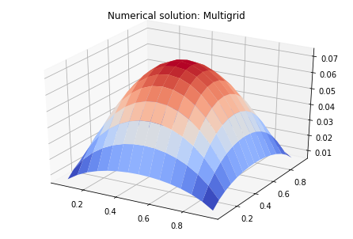

```python
# Model setup
num_channel_input = 1
num_channel_u = 1
num_channel_f = 1
num_classes = 1

J = 4
num_iteration = [1,1,1,1]  # multigrid. change this to [2,0,0,0] gives the gradient descent method
MG0=MG(num_channel_input, num_iteration, num_channel_u, num_channel_f, num_classes)

##### For MG: PDE setup u=sin(2*pi*x)*sin(2*pi*y) #####

N = 2 ** J -1
h = 1/2**J
u_exact = torch.ones(1,1,N,N)
f = torch.ones(1,1,N,N) / (N+1) **2


##### For MG: Muligrid iteration #####
M = 100
u = torch.randn(1,1,N,N)
error_mg = [np.linalg.norm((A(u)-f).detach().numpy())]

for m in range(M):
    u_list = []
    u = MG0(u,f)
    for j in range(J-1,0,-1):
        u_list[j] += RT(u_list[j+1])
    u = u_list[1]
    error_mg.append(np.linalg.norm((A(u)-f).detach().numpy()))


##### Lian added for MG: Plot results #####
plot_solution(J,u,'Numerical solution: Multigrid')
```

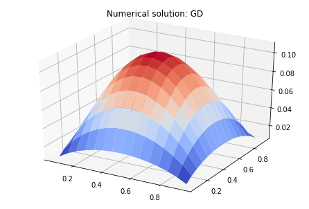

```python
# Model setup
num_channel_input = 1
num_channel_u = 1
num_channel_f = 1
num_classes = 1

J = 4
num_iteration = [1,0,0,0]  # multigrid. change this to [2,0,0,0,0] gives the gradient descent method
MG0=MG(num_channel_input, num_iteration, num_channel_u, num_channel_f, num_classes)

##### For MG: PDE setup u=sin(2*pi*x)*sin(2*pi*y) #####

N = 2 ** J -1
h = 1/2**J
u_exact = torch.ones(1,1,N,N)
f = torch.ones(1,1,N,N) / (N+1) **2


##### For MG: Muligrid iteration #####
M = 100
u = torch.randn(1,1,N,N)
error_gd = [np.linalg.norm((A(u)-f).detach().numpy())]

for m in range(M):
    u_list = []
    u = MG0(u,f)
    for j in range(J-1,0,-1):
        u_list[j] += RT(u_list[j+1])
    u = u_list[1]
    error_gd.append(np.linalg.norm((A(u)-f).detach().numpy()))


##### Lian added for MG: Plot results #####
plot_solution(J,u,'Numerical solution: GD')
```

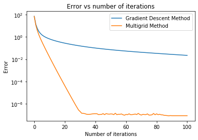

```python
plt.figure()
plt.title('Error vs number of iterations')
plot = plt.plot(error_gd,label='Gradient Descent Method')
plot = plt.plot(error_mg,label='Multigrid Method')
plt.xlabel('Number of iterations')
plt.yscale('log')
plt.ylabel('Error')
plt.legend()
plt.show()
```

[output not shown]

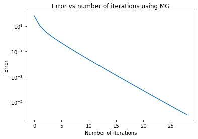

```python
# Model setup
num_channel_input = 1
num_channel_u = 1
num_channel_f = 1
num_classes = 1

J = 4
num_iteration = [1,1,1,1]  # multigrid. change this to [2,0,0,0,0] gives the gradient descent method
MG0=MG(num_channel_input, num_iteration, num_channel_u, num_channel_f, num_classes)

##### For MG: PDE setup u=sin(2*pi*x)*sin(2*pi*y) #####

N = 2 ** J -1
h = 1/2**J
u_exact = torch.ones(1,1,N,N)
f = torch.ones(1,1,N,N) / (N+1) **2


##### For MG: Muligrid iteration #####
start_mg = timer()

M = 1000
u = torch.randn(1,1,N,N)
error_gd = [np.linalg.norm((A(u)-f).detach().numpy())]

for m in range(M):
    if error_gd[-1]>1e-6:
        u_list = []
        u = MG0(u,f)
        for j in range(J-1,0,-1):
            u_list[j] += RT(u_list[j+1])
        u = u_list[1]
        error_gd.append(np.linalg.norm((A(u)-f).detach().numpy()))
    else:
        break
end_mg = timer()

print('For MG method, the minimum number of iterations to achieve less than 1e-5 error is:{}, and the computational time is: {}'.format(m, end_mg-start_mg))

plot_error(M,error_gd,'MG')
```

[output not shown]

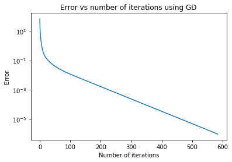

```python
# Model setup
num_channel_input = 1
num_channel_u = 1
num_channel_f = 1
num_classes = 1

J = 4
num_iteration = [1,0,0,0]  # multigrid. change this to [2,0,0,0,0] gives the gradient descent method
MG0=MG(num_channel_input, num_iteration, num_channel_u, num_channel_f, num_classes)

##### For MG: PDE setup u=sin(2*pi*x)*sin(2*pi*y) #####

N = 2 ** J -1
h = 1/2**J
u_exact = torch.ones(1,1,N,N)
f = torch.ones(1,1,N,N) / (N+1) **2


##### For MG: Muligrid iteration #####
M = 1000
u = torch.randn(1,1,N,N)
error_gd = [np.linalg.norm((A(u)-f).detach().numpy())]

start_gd = timer()
for m in range(M):
    if error_gd[-1]>1e-6:
        u_list = []
        u = MG0(u,f)
        for j in range(J-1,0,-1):
            u_list[j] += RT(u_list[j+1])
        u = u_list[1]
        error_gd.append(np.linalg.norm((A(u)-f).detach().numpy()))
    else:
        break
end_gd = timer()

print('For GD method, the minimum number of iterations to achieve less than 1e-5 error is:{}, and the computational time is: {}'.format(m, end_gd-start_gd))

plot_error(M,error_gd,'GD')
```

```python
def MG1(u,f,J,num_iteration):
    u_list.clear()                                     # Save u^0,u^1,u^2,u^3...,u^J
    u = MG0(u,f)
    for j in range(J-1,0,-1):
        u_list[j] += RT(u_list[j+1])
    u = u_list[1]
    return u
```

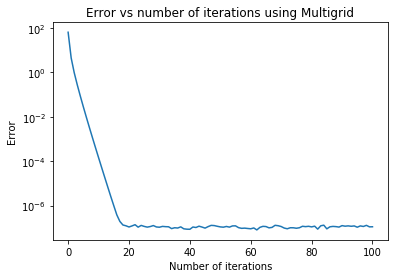

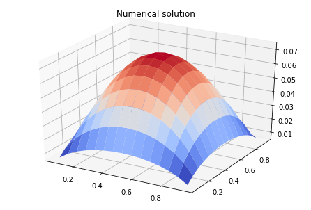

```python
# Model setup
num_channel_input = 1
num_channel_u = 1
num_channel_f = 1
num_classes = 1

J = 4
num_iteration = [2,2,2,2]
MG0=MG(num_channel_input, num_iteration, num_channel_u, num_channel_f, num_classes)

##### For MG: PDE setup u=sin(2*pi*x)*sin(2*pi*y) #####

N = 2 ** J -1
h = 1/2**J
u_exact = torch.ones(1,1,N,N)
f = torch.ones(1,1,N,N) / (N+1) **2


##### For MG: Muligrid iteration #####
M = 100
u = torch.randn(1,1,N,N)
error = [np.linalg.norm((A(u)-f).detach().numpy())]  # calculate the Frobenius Norm of (A*u-f)
u_list =[]                                     # Save u^0,u^1,u^2,u^3...,u^J

for m in range(M):
    u = MG1(u,f,J,num_iteration)
    error.append(np.linalg.norm((A(u)-f).detach().numpy())) # calculate the Frobenius Norm of (A*u-f)


##### Lian added for MG: Plot results #####
plot_error(M,error,'Multigrid')
plot_solution(J,u,'Numerical solution')
```

## Solution of Problem 2.